# Psych 254 W15 PS #2

HINT: `facets = . ~ x` puts x on the columns, but `facets = ~ x` (no dot) *wraps* the facets. These are underlying calls to different functions, `facet_wrap` (no dot) and `facet_grid` (two arguments).

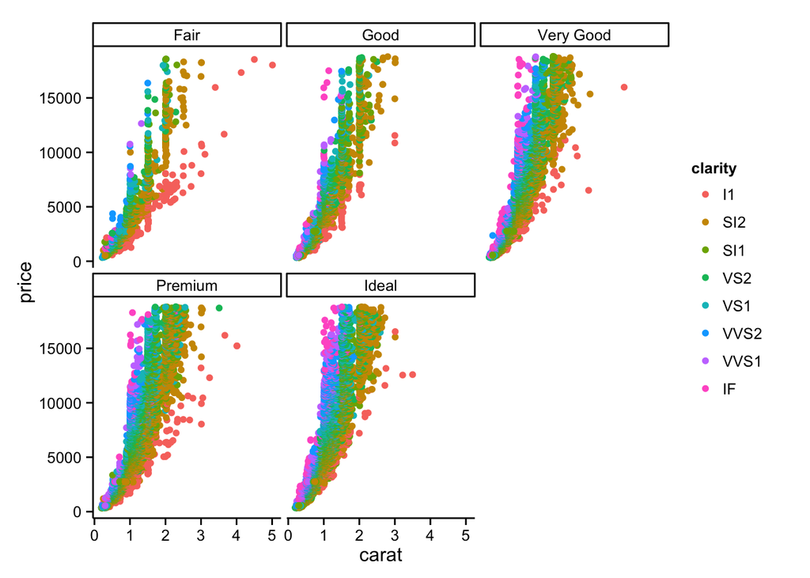

```r
ggplot(diamonds, aes(x=carat, y=price, color=clarity)) +
  theme_classic()+
  geom_point() +
  facet_wrap(~cut)
```

The basic unit of a ggplot plot is a “geom” - a mapping between data (via an “aesthetic”) and a particular geometric configuration on coordinate axes.

Let’s try some other geoms and manipulate their parameters. First, try a histogram (`geom="hist"`).

```
## stat_bin: binwidth defaulted to range/30. Use 'binwidth = x' to adjust this.
```

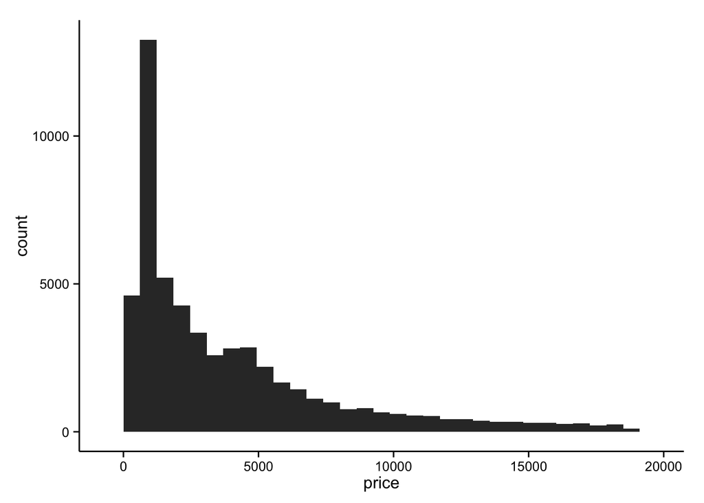

```r
ggplot(diamonds, aes(x=price)) +
  theme_classic()+
  geom_histogram()
```

Now facet your histogram by clarity and cut.

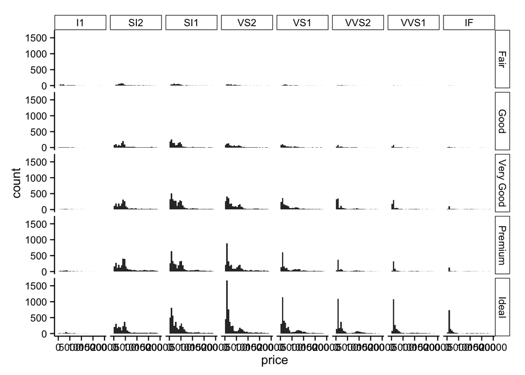

```r
ggplot(diamonds, aes(x=price)) +
  theme_classic() +
  geom_histogram() +
  facet_grid(cut ~ clarity)
```

I like a slightly cleaner look to my plots. Luckily, ggplot allows you to add “themes” to your plots. Try doing the same plot but adding `+ theme_bw()` or `+ theme_classic()`. Different themes work better for different applications, in my experience.

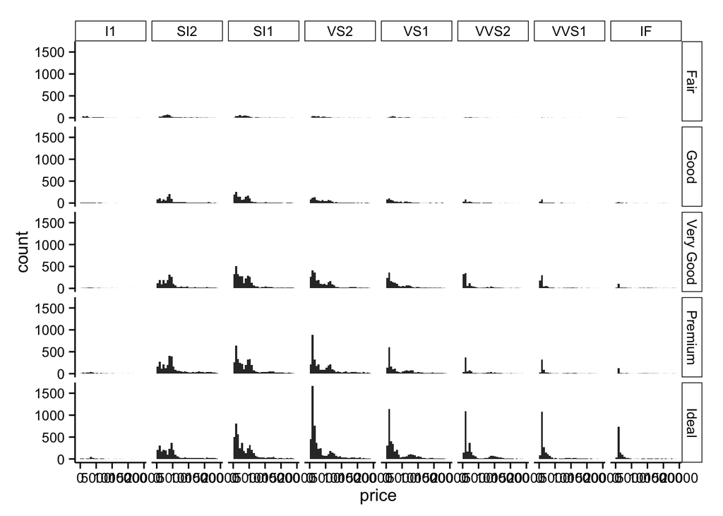

```r
ggplot(diamonds, aes(x=price)) +
  theme_classic() +
  geom_histogram() +
  facet_grid(cut ~ clarity)
```